# Solutions to Applied Predictive Modeling (Kuhn and Johnson, 2013)

Chapter 7 - Exercise 7.1

by Brian Hassett

# Introduction

This notebook outlines a solution to the exercise using the `tidymodels` package to implement the modeling. My previous solution provides an implementation using for loops and the `kernlab::ksvm()` function. In this notebook I have avoided loops and instead use the model building process that `tidymodels` is designed for. The basic idea is to fit a model on all of the training data, then make predictions on a regular grid of predictor values. The `tidymodels` workflow facilitates doing this for many candidate models by using a grid of parameters. This is explained throughout the code below.

# Exercise Instructions

*Instructions adapted from Kuhn and Johnson (2013)[^1].*

Simulate a single predictor and a nonlinear relationship, such as a sine wave shown in Fig. 7.7, and investigate the relationship between the cost, epsilon, and kernel parameters for a support vector machine model.

1. Fit different models using a radial basis function and different values of the cost and epsilon. Plot the fitted curve.
2. Try different values of sigma to understand how this parameter changes the model fit. How do the cost, epsilon, and sigma values affect the model?

# (a)

## Data

Simulate a single predictor and a nonlinear relationship (sine wave):

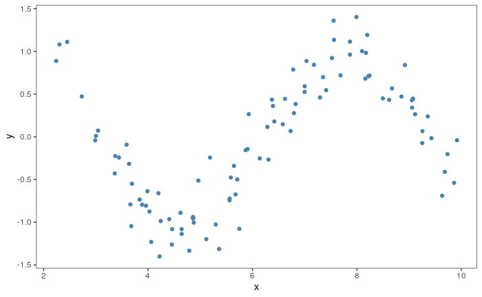

```r
set.seed(100)
x <- runif(100, min = 2, max = 10)
y <- sin(x) + rnorm(length(x)) * 0.25
df1 <- data.frame(x = x, y = y)

ggplot(df1, aes(x, y)) +
  geom_point(color = "steelblue") +
  theme(panel.grid = element_blank())
```

## SVM (Radial Basis Function) with varying values for `cost` and `margin`

This model building process is different to the process used throughout the chapter in that it uses simulated data rather than real data. Rather than making the most accurate prediction, we are interested in how the predictions change as the parameters change. Therefore we don’t need a training or test split, and don’t need to perform cross-validation. Instead, we train a range of models with varying parameters using all of the simulated data, make predictions using a grid of values, and plot the results.

### Data

There is no splitting or resampling required. We use ALL of the simulated data for building and fitting the models:

### Grid of parameters

Create a grid of parameters to use. We will only use `cost` and `margin` for now (part (b) explores `rbf_sigma`):

```r
svm_rbf_grid <- expand.grid(cost = 2^c(-2, 0, 2, 8), margin = c(0.01, 0.05, 0.1, 0.5))
```

### Models specs

Create a list of models, each one with a set of parameters from the grid created above:

```r
svm_rbf_mods <- pmap(svm_rbf_grid, svm_rbf)
# Ref: Docs for pmap() has a simple example using gsub() with a data frame of arguments
```

### Fit models

Fit each of the models on the simulated data. (There may be a more compact way of specifying the model parameters as well as the mode and engine in one go. Here I have specified the models and parameters above using `pmap()`, then I set the mode and engine using `map()` before passing it on to `fit()` below):

```r
set.seed(1)
svm_rbf_fits <- svm_rbf_mods %>%
  map(function(mod) {
    fit <- mod %>%
      set_engine("kernlab") %>%
      set_mode("regression") %>%
      parsnip::fit(y ~ x, data = df1)
  })
```

### Predictions

Create a grid of values for prediction:

```r
prediction_grid <- data.frame(x = seq(2, 10, length = 100))
```

Pass the grid of values to the models to make predictions:

```r
preds <- svm_rbf_fits %>%
  map(~predict(., new_data = prediction_grid))
```

### Plot results

I used three methods (`map()`, `facet_wrap()` and `facet_grid()`) to do the plot. The `facet_grid()` method is the best as it automatically creates the facet labels and is much better for part (b) where I need to use a color aesthetic for a third parameter:

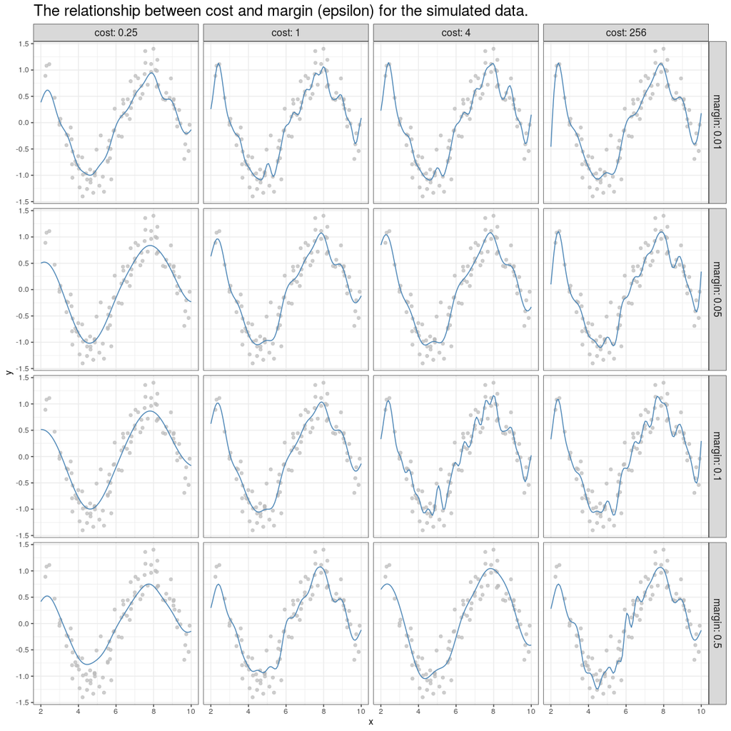

```r
# Add id column to the grid of candidate values for facilitating joins later:
n <- nrow(svm_rbf_grid)
svm_rbf_grid <- svm_rbf_grid %>%
  mutate(id = as.character(row_number())) # need characters so that I can join with the predictions

# Create a long-form data frame grid of the predictions and the associated parameters:
preds_long <- cbind(prediction_grid, bind_cols(preds)) %>%
  set_names(c("x", 1:n)) %>% # rename the columns so they can be used as id's to join with svm_rbf_grid
  pivot_longer(cols = '1':'16', names_to = "id", values_to = ".pred") %>%
  left_join(svm_rbf_grid, by = "id")

# Plot:
ggplot() +
  geom_point(data = df1, aes(x, y),
             color = "grey", alpha = 0.75) +
  geom_line(data = preds_long, aes(x, .pred),
            color = "steelblue") +
  facet_grid(margin ~ cost, labeller = label_both) + # *1
  ggtitle("The relationship between cost and margin (epsilon) for the simulated data.") +
  theme(plot.title = element_text(size = 18),
        strip.text = element_text(size = 12))
```

```r
# *1: This tutorial provides examples for labeling facets: https://www.datanovia.com/en/blog/how-to-change-ggplot-facet-labels/
```

*Adapted from Kuhn and Johnson (2013)*:

The above plot shows the training data and the regression curve for each model fit. Generally speaking, the regression model becomes more jagged as the `cost` value increases. This is due to the training process putting a cost on the residual values. As a result, higher cost values will motivate the training process to minimize the residuals on the training set data as much as possible. This leads to models with lower bias and higher variability (i.e. the fit is likely to change if the data changes). The effect of `margin` (`epsilon`) is similar but not as potent. As `margin` decreases the model fit begins to overfit more. This effect is smaller than the `cost` effect. For example, in the left–most column, the amount of overfitting is negligible. However, in the right–most column, the overfitting effect can be seen the most at the extremes of the x–axis where the model fit changes more radically as `margin` becomes small.

# (b)

This process is mostly adapted from part (a).

## SVM (Radial Basis Function) with varying values for `cost`, `margin` and `rbf_sigma`

### Grid of parameters

Create an updated grid of parameters to use. We are varying `cost`, `margin` and `rbf_sigma`:

```r
svm_rbf_grid <- expand.grid(cost = 2^c(-2, 0, 2, 8),
                            margin = c(0.01, 0.05, 0.1, 0.5),
                            rbf_sigma = kernlab::sigest(y ~ x, data = df1, frac = .75)) # *1
# *1: These values are different to the text, presumably because the implementation of the `sigest` function changed.
```

### Models specs

Create a list of models, each one with a set of parameters from the grid created above:

```r
svm_rbf_mods_b <- pmap(svm_rbf_grid, svm_rbf)
```

### Fit models

Fit each of the models on the simulated data. (There may be a more compact way of specifying the model parameters as well as the mode and engine in one go. Here I have specified the models and parameters above using `pmap()`, then I set the mode and engine using `map()` before passing it on to `fit()` below):

```r
set.seed(1)
svm_rbf_fits_b <- svm_rbf_mods_b %>%
  map(function(mod) {
    fit <- mod %>%
      set_engine("kernlab") %>%
      set_mode("regression") %>%
      parsnip::fit(y ~ x, data = df1)
  })
#Ref: https://www.tidymodels.org/start/models/#build-model
```

### Predictions

Pass the grid of values to the models to make predictions:

```r
preds <- svm_rbf_fits_b %>%
  map(~predict(., new_data = prediction_grid))
```

### Plot results

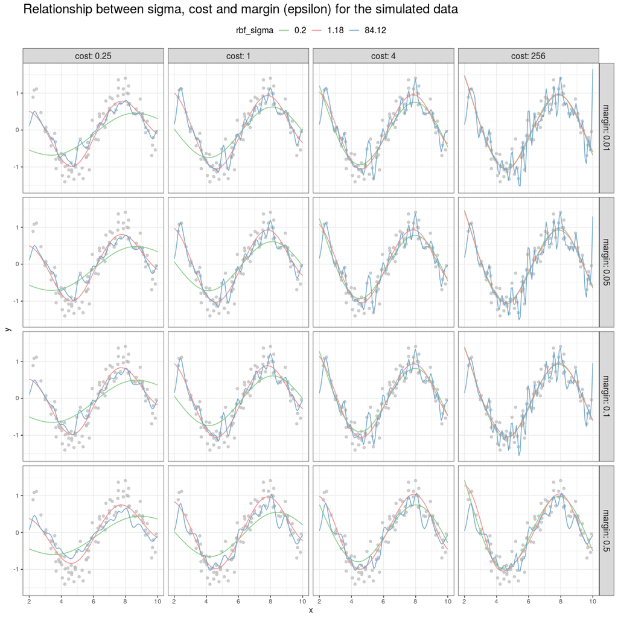

```r
# Add id column to the grid of candidate values for facilitating joins later:
n <- nrow(svm_rbf_grid)
svm_rbf_grid <- svm_rbf_grid %>%
  mutate(id = as.character(row_number())) # need characters so that I can join with the predictions

# Create a long-form data frame grid of the predictions and the associated parameters:
preds_long <- cbind(prediction_grid, bind_cols(preds)) %>%
  set_names(c("x", 1:n)) %>% # rename the columns so they can be used as id's to join with svm_rbf_grid
  pivot_longer(cols = '1':'48', names_to = "id", values_to = ".pred") %>%
  left_join(svm_rbf_grid, by = "id") %>%
  mutate(rbf_sigma = factor(round(rbf_sigma, 2)))

# Colors:
green <- "#82CA82"
red <- "#F28C8C"
blue <- "#70A6CA"

# Plot:
ggplot() +
  geom_point(data = df1, aes(x, y),
             color = "grey", alpha = 0.75) +
  geom_line(data = preds_long, aes(x, .pred,color = rbf_sigma)) +
  facet_grid(margin ~ cost, labeller = label_both) +
  scale_color_manual(values = c(green, red, blue)) +
  theme(legend.position = "top",
        legend.title = element_text(size = 12),
        legend.text = element_text(size = 12),
        plot.title = element_text(size = 18),
        strip.text = element_text(size = 12)) +
  ggtitle("Relationship between sigma, cost and margin (epsilon) for the simulated data")
```

*Adapted from Kuhn and Johnson (2013)*:

The above plot shows the fitted regression curves. The effect of `rbf_sigma` is complex. For low to moderate `cost` values, `rbf_sigma` appears to affect the model bias. For example, in the left column (i.e. low `cost`) the curves are dynamic in `rbf_sigma`; the low value tends to underfit the data, while high value tends to overfit the data. As `cost` increases, the low and mid value of `rbf_sigma` are similar, while the high value still tends to overfit. This low-dimensional example illustrates the powerful fitting ability that SVMs have through the tuning parameters. Clearly SVMs are prone to overfitting and must be appropriately trained/tuned to protect against overfitting to the training data.

[^1]: Kuhn M, Johnson K (2013). *Applied Predictive Modeling*. Springer.